# Cookie Cats AB Test Analysis

Alexandra Lugo

2026-02-16

# 1. Problem Statement & Hypothesis

**Business Context:** Cookie Cats is a mobile puzzle game where players encounter “gates” that force them to wait or make in-app purchases to progress. The company tested moving the first gate from level 30 to level 40 to see if this impacts players retention.

**Research Question:** Does moving the gate from level 30 to level 40 affect 1-day and 7-day player retention?

**Hypotheses:**

- **Null Hypothesis (H₀):** Gate placement has no effect on retention rates
- **Alternative Hypothesis (H₁):** Gate placement significantly affects retention rates

**Success Metrics:**

- **Primary:** 7-day retention rate (retention_7)
- **Secondary:** 1-day retention rate (retention_1)
- **Significance Level:** α = 0.05

# 2. Setup & Data Loading

```r
#load required libraries
library(tidyverse)
library(scales)
library(knitr)
library(broom)
```

```r
#import dataset
df <- read_csv("cookie_cats.csv")

#display structure
glimpse(df)
```

```
## Rows: 90,189
## Columns: 5
## $ userid         <dbl> 116, 337, 377, 483, 488, 540, 1066, 1444, 1574, 1587, 1…
## $ version        <chr> "gate_30", "gate_30", "gate_40", "gate_40", "gate_40", …
## $ sum_gamerounds <dbl> 3, 38, 165, 1, 179, 187, 0, 2, 108, 153, 3, 0, 30, 39, …
## $ retention_1    <lgl> FALSE, TRUE, TRUE, FALSE, TRUE, TRUE, FALSE, FALSE, TRU…
## $ retention_7    <lgl> FALSE, FALSE, FALSE, FALSE, TRUE, TRUE, FALSE, FALSE, T…
```

# 3. Data Quality Checks

```r
#check for missing values
cat("Missing values by column:\n")
```

```
## Missing values by column:
```

```r
colSums(is.na(df))
```

```
##         userid        version sum_gamerounds    retention_1    retention_7
##              0              0              0              0              0
```

```r
#summary statistics
summary(df)
```

```
##      userid          version          sum_gamerounds     retention_1
##  Min.   :    116   Length:90189       Min.   :    0.00   Mode :logical
##  1st Qu.:2512230   Class :character   1st Qu.:    5.00   FALSE:50036
##  Median :4995815   Mode  :character   Median :   16.00   TRUE :40153
##  Mean   :4998412                      Mean   :   51.87
##  3rd Qu.:7496452                      3rd Qu.:   51.00
##  Max.   :9999861                      Max.   :49854.00
##  retention_7
##  Mode :logical
##  FALSE:73408
##  TRUE :16781
##
##
##
```

```r
#check unique values in version column
cat("\nUnique gate versions:\n")
```

```
##
## Unique gate versions:
```

```r
table(df$version)
```

```
##
## gate_30 gate_40
##   44700   45489
```

# 4. Exploratory Data Analysis

## Sample Size by Group

```r
#Create summary table
sample_summary <- df %>%
  group_by(version) %>%
  summarise(
    n_players = n(),
    pct_of_total = percent(n() / nrow(df), accuracy = 0.1)
  ) %>%
  arrange(desc(n_players))

kable(sample_summary, col.names = c("Gate Version", "Number of Players", "% of Total"),
      caption = "Sample Size Distribution by Test Group")
```

Sample Size Distribution by Test Group

| Gate Version | Number of Players | % of Total |
| --- | --- | --- |
| gate_40 | 45489 | 50.4% |
| gate_30 | 44700 | 49.6% |

```r
# calculate baseline retention rates
retention_summary <- df %>%
  group_by(version) %>%
  summarise(
    n_players = n(),
    retention_1_rate = mean(retention_1, na.rm = TRUE),
    retention_7_rate = mean(retention_7, na.rm = TRUE),
    avg_game_rounds = mean(sum_gamerounds, na.rm = TRUE)
  )

kable(retention_summary, digits=3, col.names = c("Gate Version", "Players", "Day 1 Retention ", "Day 7 Retention ", "Avg Game Rounds"),
      caption = "Baseline Metricsby Test Group")
```

Baseline Metricsby Test Group

| Gate Version | Players | Day 1 Retention | Day 7 Retention | Avg Game Rounds |
| --- | --- | --- | --- | --- |
| gate_30 | 44700 | 0.448 | 0.190 | 52.456 |
| gate_40 | 45489 | 0.442 | 0.182 | 51.299 |

## Initial Observations

Based on the descriptive statistics:

- **Sample sizes are well-balanced:** 44,700 vs 45,489 players (49.6% vs 50.4%)
- **Day 1 retention:** gate_30 shows 44.8% retention vs gate_40’s 44.2% (0.6 percentage point difference)
- **Day 7 retention:** gate_30 shows 19.0% retention vs gate_40’s 18.2% (0.8 percentage point difference)
- **Engagement levels:** Both groups played similar average rounds (~51-52 rounds)

**Next step:** Determine if these observed differences are statistically significant or due to random chance.

## Viz 1: Retention Rate Comparison with Confidence Intervals

### Confidence Intervals for Retention Rates

```r
# ===== Calculate confidence intervals for retention rates =====
retention_ci <- df %>%
  group_by(version) %>%
  summarise(
    n = n(),
    #day 1 retention
    retention_1_rate = mean(retention_1),
    retention_1_se = sqrt(retention_1_rate * (1 - retention_1_rate) / n),
    retention_1_ci_lower = retention_1_rate -  1.96 * retention_1_se,
    retention_1_ci_upper = retention_1_rate +  1.96 * retention_1_se,
    # day 7 retention
    retention_7_rate = mean(retention_7),
    retention_7_se = sqrt(retention_7_rate * (1 - retention_7_rate) / n),
    retention_7_ci_lower = retention_7_rate - 1.96 * retention_7_se,
    retention_7_ci_upper = retention_7_rate + 1.96 * retention_7_se
  )

#view results
retention_ci
```

```
## # A tibble: 2 × 10
##   version     n retention_1_rate retention_1_se retention_1_ci_lower
##   <chr>   <int>            <dbl>          <dbl>                <dbl>
## 1 gate_30 44700            0.448        0.00235                0.444
## 2 gate_40 45489            0.442        0.00233                0.438
## # ℹ 5 more variables: retention_1_ci_upper <dbl>, retention_7_rate <dbl>,
## #   retention_7_se <dbl>, retention_7_ci_lower <dbl>,
## #   retention_7_ci_upper <dbl>
```

### Plot 1: Day 1 Retention Comparison

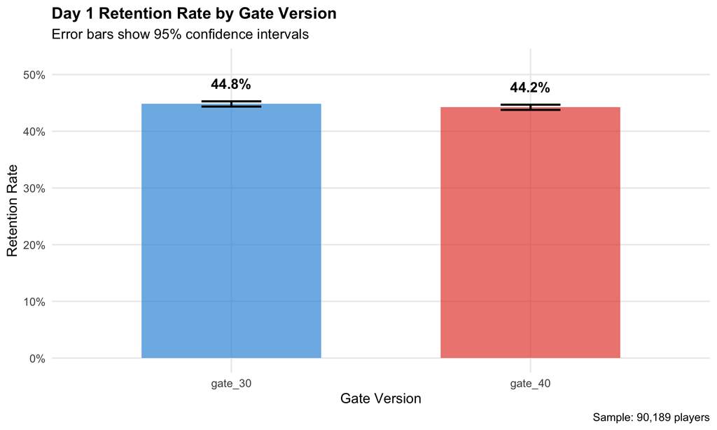

```r
# ===== PLOT 1: Day 1 Retention Comparison (FIXED SPACING) =====
ggplot(retention_ci, aes(x = version, y = retention_1_rate, fill = version)) +
  geom_col(alpha = 0.7, width = 0.6) +
  geom_errorbar(aes(ymin = retention_1_ci_lower, ymax = retention_1_ci_upper),
                width = 0.2, linewidth = 1) +
  geom_text(aes(label = percent(retention_1_rate, accuracy = 0.1)),
            vjust = -1.5, size = 5, fontface = "bold") +  # Changed vjust from -0.5 to -1.5
  scale_y_continuous(labels = percent_format(),
                     limits = c(0, 0.52),  # Changed from 0.5 to 0.52
                     breaks = seq(0, 0.5, 0.1)) +
  scale_fill_manual(values = c("gate_30" = "#3498db", "gate_40" = "#e74c3c")) +
  labs(
    title = "Day 1 Retention Rate by Gate Version",
    subtitle = "Error bars show 95% confidence intervals",
    x = "Gate Version",
    y = "Retention Rate",
    caption = "Sample: 90,189 players"
  ) +
  theme_minimal(base_size = 14) +
  theme(
    legend.position = "none",
    plot.title = element_text(face = "bold", size = 16),
    panel.grid.minor = element_blank()
  )
```

### Plot 2: Day 7 Retention Comparison

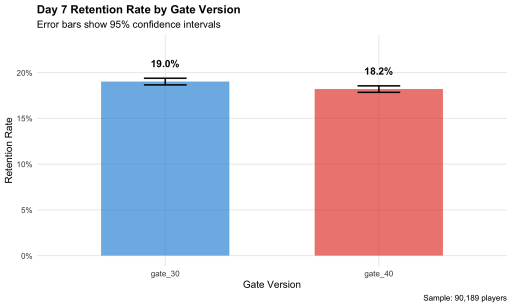

```r
ggplot(retention_ci, aes(x = version, y = retention_7_rate, fill = version)) +
  geom_col(alpha = 0.7, width = 0.6) +
  geom_errorbar(aes(ymin = retention_7_ci_lower, ymax = retention_7_ci_upper),
                width = 0.2, linewidth = 1) +
  geom_text(aes(label = percent(retention_7_rate, accuracy = 0.1)),
            vjust = -2.0, size = 5, fontface = "bold") +  # Changed to -2.0 for more space
  scale_y_continuous(labels = percent_format(),
                     limits = c(0, 0.23),  # Increased from 0.22 to 0.23
                     breaks = seq(0, 0.25, 0.05)) +
  scale_fill_manual(values = c("gate_30" = "#3498db", "gate_40" = "#e74c3c")) +
  labs(
    title = "Day 7 Retention Rate by Gate Version",
    subtitle = "Error bars show 95% confidence intervals",
    x = "Gate Version",
    y = "Retention Rate",
    caption = "Sample: 90,189 players"
  ) +
  theme_minimal(base_size = 14) +
  theme(
    legend.position = "none",
    plot.title = element_text(face = "bold", size = 16),
    panel.grid.minor = element_blank()
  )
```

## Viz 2: Sample Size Sanity Check

### Sample Size Distribution Plot

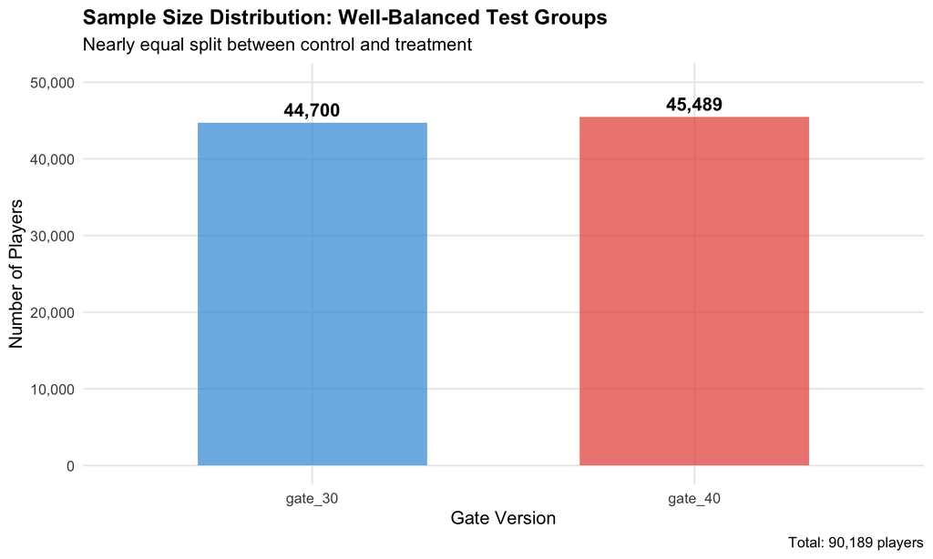

```r
# ===== PLOT 3: Sample Size Distribution =====
ggplot(sample_summary, aes(x = version, y = n_players, fill = version)) +
  geom_col(alpha = 0.7, width = 0.6) +
  geom_text(aes(label = comma(n_players)), vjust = -0.5, size = 5, fontface = "bold") +
  scale_y_continuous(labels = comma_format(), limits = c(0, 50000), breaks = seq(0, 50000, 10000)) +
  scale_fill_manual(values = c("gate_30" = "#3498db", "gate_40" = "#e74c3c")) +
  labs(
    title = "Sample Size Distribution: Well-Balanced Test Groups",
    subtitle= "Nearly equal split between control and treatment",
    x = "Gate Version",
    y = "Number of Players",
    caption = "Total: 90,189 players"
  ) +
  theme_minimal(base_size = 14) +
  theme(
    legend.position = "none",
    plot.title = element_text(face = "bold", size = 16),
    panel.grid.minor = element_blank()
  )
```

## Visual Interpretation

The bar charts reveal:

1. **Day 1 Retention:** gate_30 (44.8%) slightly outperforms gate_40 (44.2%), but confidence intervals overlap heavily - suggesting the difference may be due to random variation.
2. **Day 7 Retention:** The gap widens at the 7-day mark (19.0% vs 18.2%). This 0.8 percentage point difference is more substantial and warrants statistical investigation.
3. **Sample Balance:** Both groups have ~45,000 players, confirming proper randomization and sufficient statistical power.

**Statistical testing will determine if these observed differences are significant or merely noise.**

# 5. Statistical Hypothesis Testing

We’ll use **two-proportion z-tests** to determine if the observed differences in retention rates are statistically significant.

**Test Setup:**

- Null Hypothesis (H₀): Retention rates are equal between groups
- Alternative Hypothesis (H₁): Retention rates differ between groups
- Significance level: α = 0.05
- Test: Two-proportion z-test (appropriate for comparing two proportions)

## Day 1 Retention Z-Test

```r
# ===== Day 1 Retention Test =====

#prepare data for day 1
gate_30_day1 <- df %>% filter(version == "gate_30")
gate_40_day1 <- df %>% filter(version == "gate_40")

#count successes (retained players)
n_30_day1 <- nrow(gate_30_day1)
n_40_day1 <- nrow(gate_40_day1)
retained_30_day1 <- sum(gate_30_day1$retention_1)
retained_40_day1 <- sum(gate_40_day1$retention_1)

#perform two-proportion z-test
day1_test <- prop.test(x = c(retained_30_day1, retained_40_day1),
                          n = c(n_30_day1, n_40_day1),
                          alternative = "two.sided",
                          conf.level = 0.95,
                          correct = FALSE)
#display results
day1_test
```

```
##
##  2-sample test for equality of proportions without continuity correction
##
## data:  c(retained_30_day1, retained_40_day1) out of c(n_30_day1, n_40_day1)
## X-squared = 3.183, df = 1, p-value = 0.07441
## alternative hypothesis: two.sided
## 95 percent confidence interval:
##  -0.0005820999  0.0123924394
## sample estimates:
##    prop 1    prop 2
## 0.4481879 0.4422827
```

### Extract Key Metrics for Day 1

```r
# ===== Extract Key Metrics for Day 1 Test =====

#calculate proportions and effect size
p_30_day1 <- retained_30_day1 / n_30_day1
p_40_day1 <- retained_40_day1 / n_40_day1
effect_size_day1 <- p_30_day1 - p_40_day1

#create results table
day1_results <- data.frame(
  Metric = c("gate_30 Retention Rate",
  "gate_40 Retention Rate",
  "Difference (gate_30 - gate_40)",
  "95% CI Lower Bound",
  "95% CI Upper Bound",
  "Z-statistic",
  "P-value",
  "Statistically Significant?"),
  Value = c(percent(p_30_day1, accuracy = 0.01),
            percent(p_40_day1, accuracy = 0.01),
            percent(effect_size_day1, accuracy = 0.01),
            percent(day1_test$conf.int[1], accuracy = 0.01),
            percent(day1_test$conf.int[2], accuracy = 0.01),
            as.character(round(sqrt(day1_test$statistic), 3)),
            format(day1_test$p.value, scientific = TRUE, digits = 3),
            ifelse(day1_test$p.value < 0.05, "Yes (p < 0.05)", "No (p >= 0.05)"))
)

kable(day1_results, caption = "Day 1 Retention Test Results")
```

Day 1 Retention Test Results

| Metric | Value |
| --- | --- |
| gate_30 Retention Rate | 44.82% |
| gate_40 Retention Rate | 44.23% |
| Difference (gate_30 - gate_40) | 0.59% |
| 95% CI Lower Bound | -0.06% |
| 95% CI Upper Bound | 1.24% |
| Z-statistic | 1.784 |
| P-value | 7.44e-02 |
| Statistically Significant? | No (p >= 0.05) |

## Day 7 Retention Z-Test

```r
# ===== Day 7 Retention Test =====

#count successes (retained players at day 7)
retained_30_day7 <- sum(gate_30_day1$retention_7)
retained_40_day7 <- sum(gate_40_day1$retention_7)

#perform two-proportion z-test for day 7
day7_test <- prop.test(x = c(retained_30_day7, retained_40_day7),
                          n = c(n_30_day1, n_40_day1),
                          alternative = "two.sided",
                          conf.level = 0.95,
                          correct = FALSE)
#display results
day7_test
```

```
##
##  2-sample test for equality of proportions without continuity correction
##
## data:  c(retained_30_day7, retained_40_day7) out of c(n_30_day1, n_40_day1)
## X-squared = 10.013, df = 1, p-value = 0.001554
## alternative hypothesis: two.sided
## 95 percent confidence interval:
##  0.003121044 0.013281552
## sample estimates:
##    prop 1    prop 2
## 0.1902013 0.1820000
```

### Extract Key Metrics for Day 7

```r
# ===== Extract Key Metrics for Day 7 Test =====

#calculate proportions and effect size for day 7
p_30_day7 <- retained_30_day7 / n_30_day1
p_40_day7 <- retained_40_day7 / n_40_day1
effect_size_day7 <- p_30_day7 - p_40_day7

#create results table for day 7
day7_results <- data.frame(
  Metric = c("gate_30 Retention Rate",
  "gate_40 Retention Rate",
  "Difference (gate_30 - gate_40)",
  "95% CI Lower Bound",
  "95% CI Upper Bound",
  "Z-statistic",
  "P-value",
  "Statistically Significant?"),
  Value = c(percent(p_30_day7, accuracy = 0.01),
            percent(p_40_day7, accuracy = 0.01),
            percent(effect_size_day7, accuracy = 0.01),
            percent(day7_test$conf.int[1], accuracy = 0.01),
            percent(day7_test$conf.int[2], accuracy = 0.01),
            as.character(round(sqrt(day7_test$statistic), 3)),
            format(day7_test$p.value, scientific = TRUE, digits = 3),
            ifelse(day7_test$p.value < 0.05, "Yes (p < 0.05)", "No (p >= 0.05)"))
)

kable(day7_results, caption = "Day 7 Retention Test Results")
```

Day 7 Retention Test Results

| Metric | Value |
| --- | --- |
| gate_30 Retention Rate | 19.02% |
| gate_40 Retention Rate | 18.20% |
| Difference (gate_30 - gate_40) | 0.82% |
| 95% CI Lower Bound | 0.31% |
| 95% CI Upper Bound | 1.33% |
| Z-statistic | 3.164 |
| P-value | 1.55e-03 |
| Statistically Significant? | Yes (p < 0.05) |

## Comparison Viz: Confidence Intervals

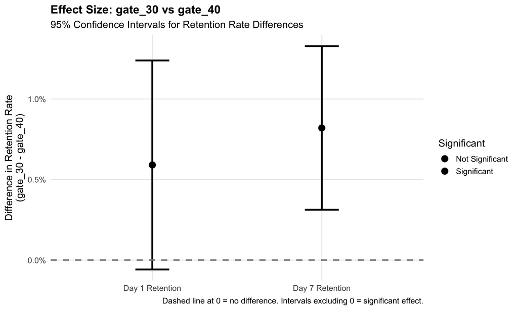

```r
# ===== PLOT 4: Retention Rate Comparison with Confidence Intervals =====

ci_comparison <- data.frame(
  Metric = c("Day 1 Retention", "Day 7 Retention"),
  Difference = c(effect_size_day1, effect_size_day7),
  CI_Lower = c(day1_test$conf.int[1], day7_test$conf.int[1]),
  CI_Upper = c(day1_test$conf.int[2], day7_test$conf.int[2]),
  Significant = c(
    ifelse(day1_test$p.value < 0.05, "Significant", "Not Significant"),
    ifelse(day7_test$p.value < 0.05, "Significant", "Not Significant")
  )
)

ggplot(ci_comparison, aes(x = Metric, y = Difference, fill = Significant)) +
  geom_point(size=4) +
  geom_errorbar(aes(ymin = CI_Lower, ymax = CI_Upper), width = 0.2, linewidth = 1.2) +
  geom_hline(yintercept = 0, linetype='dashed', color='gray50', linewidth=1) +
  scale_y_continuous(labels = percent_format(), breaks = seq(-0.01, 0.01, 0.005)) +
  scale_color_manual(values = c("Significant" = "#27ae60", "Not Significant" = "#e74c3c")) +
  labs(
    title = "Effect Size: gate_30 vs gate_40",
    subtitle = "95% Confidence Intervals for Retention Rate Differences",
    x = NULL,
    y = "Difference in Retention Rate\n(gate_30 - gate_40)",
    caption = "Dashed line at 0 = no difference. Intervals excluding 0 = significant effect."
  ) +
  theme_minimal(base_size = 14) +
  theme(
    legend.position = "right",
    plot.title = element_text(face = "bold", size = 16),
    panel.grid.minor = element_blank()
  )
```

## Key Findings

Based on the two-proportion z-tests:

**Day 1 Retention:**

- **Effect size:** 0.59% (gate_30 retained more players)
- **P-value:** 0.0744
- **Conclusion:** **Not statistically significant** - The difference could be due to random variation.

**Day 7 Retention:**

- **Effect size:** 0.82% (gate_30 retained more players)
- **P-value:** 0.00155
- **Conclusion:** **Statistically significant** - The difference is unlikely due to chance.

**Overall Assessment:** The 7-day retention metric shows a stronger effect and is the more reliable indicator of long-term player behavior.

## Business Impact Estimation

```r
# ===== Business Impact Calculation =====

#assumptions
total_new_players_per_month <- 1000000  # 1M new players/month (example)
average_revenue_per_retained_player <- 2.50  # $2.50 LTV for 7-day retained players

#calculate impact
retention_loss_pct <- effect_size_day7  # 0.82% fewer players retained
players_lost_per_month <- total_new_players_per_month * retention_loss_pct
revenue_lost_per_month <- players_lost_per_month * average_revenue_per_retained_player
revenue_lost_per_year <- revenue_lost_per_month * 12

#create impact table
business_impact <- data.frame(
  Metric = c(
    "7-Day Retention Loss",
    "Players Lost per Month (1M new players)",
    "Monthly Revenue Impact ($2.50 LTV)",
    "Annual Revenue Impact"
  ),
  Value = c(
    percent(retention_loss_pct, accuracy = 0.01),
    comma(players_lost_per_month),
    dollar(revenue_lost_per_month),
    dollar(revenue_lost_per_year)
  )
)

kable(business_impact,
      caption = "Estimated Business Impact of Moving Gate to Level 40")
```

Estimated Business Impact of Moving Gate to Level 40

| Metric | Value |
| --- | --- |
| 7-Day Retention Loss | 0.82% |
| Players Lost per Month (1M new players) | 8,201 |
| Monthly Revenue Impact ($2.50 LTV) | $20,503.25 |
| Annual Revenue Impact | $246,039 |